# Class 13 OLS Regression Advanced

Author

Affiliation

Dr Wei Miao

UCL School of Management

Published

November 15, 2023

# 1 Categorical Variables

## 1.1 Categorical variables

```r
pacman::p_load(dplyr,ggplot2,ggthemes)
# Load both datasets
data_purchase <- read.csv(file = "https://www.dropbox.com/s/126e9vkq80y9ti9/purchase.csv?dl=1",
                      header = T)

data_demo <- read.csv("https://www.dropbox.com/s/hbrgktcz98y0igs/demographics.csv?dl=1",
                      header = T)

# Left join demographic data into purchase data
data_full <- data_purchase %>%
  left_join(data_demo, by = "ID")

# Handle Missing Values of Income
data_full <- data_full %>%
  mutate(Income = replace(Income, is.na(Income), mean(Income,na.rm =T))) %>%
  mutate(total_spending = MntFishProducts + MntFruits + MntGoldProds + MntMeatProducts + MntSweetProducts + MntWines)
```

- So far, the independent variables we have used are `Income` and `Kidhome`, which are **continuous variables**.
- Some variables are intrinsically not countable; we need to treat them as **categorical variables**
  - e.g., gender, education group, city.

## 1.2 Handling Categorical Variables using `factor()`

- In R, we need to use a function `factor()` to inform R that this variable is a categorical variable, such that statistical models will treat them differently from continuous variables.
  - Refer to this [link](https://www.datacamp.com/tutorial/factors-in-r) for more examples in datacamp.
- We can use `factor(Education)` to indicate that, `Education` is a categorical variable.

```r
data_full <- data_full %>%
  mutate(Education_factor = factor(Education))
```

- We can use `levels()` to check how many categories are there in the factor variable.

```r
# check levels of a factor
levels(data_full$Education_factor)
```

```
[1] "2n Cycle"   "Basic"      "Graduation" "Master"     "PhD"
```

```r
data_full <- data_full %>%
  mutate(Education_factor_2 = relevel(Education_factor, ref = "Basic") )

levels(data_full$Education_factor_2)
```

```
[1] "Basic"      "2n Cycle"   "Graduation" "Master"     "PhD"
```

## 1.3 Running Regression with Factor Variables

```r
pacman::p_load(fixest,modelsummary)
feols_categorical <- feols(data = data_full,
  fml = total_spending ~ Income + Kidhome + Education_factor_2)
modelsummary(feols_categorical,
             stars = T)
```

|  | (1) |
| --- | --- |
| (Intercept) | −180.297** |
|  | (56.305) |
| Income | 0.020*** |
|  | (0.000) |
| Kidhome | −227.761*** |
|  | (16.961) |
| Education_factor_22n Cycle | −164.044** |
|  | (60.448) |
| Education_factor_2Graduation | −119.695* |
|  | (56.176) |
| Education_factor_2Master | −143.015* |
|  | (58.443) |
| Education_factor_2PhD | −153.190** |
|  | (57.751) |
| Num.Obs. | 2000 |
| R2 | 0.662 |
| R2 Adj. | 0.661 |
| AIC | 29128.2 |
| BIC | 29167.4 |
| RMSE | 350.59 |
| Std.Errors | IID |

+ p < 0.1, * p < 0.05, ** p < 0.01, *** p < 0.001

## 1.4 Interpretation of Coefficients for Categorical Variables

- Internally, R uses **one-hot encoding** to encode factor variables with **K** levels into **K-1** binary variables.
  - Because we have the intercept, we can only have K-1 binary variables.
  - The intercept stands for the effects of the baseline group.
  - In the regression result table, `Basic` group is suppressed if we use `Education_factor_2`, because this group is chosen as the **baseline group**.
- The interpretation template of coefficients for factor variables: Ceteris paribus, compared with the [baseline group], the [outcome variable] of [group XXX] is higher/lower by [coefficient], and the coefficient is statistically [significant/insignificant].
  - Ceteris paribus, compared with the basic education group, the total spending of PhD group is lower by 153.190 dollars. The coefficient is statistically significant at the 1% level.

> After-class exercise: change the baseline group to Master, rerun the regression, and interpret the coefficients.

# 2 Non-linear Effects

## 2.1 Quadratic Terms

- If we believe the relationship between the outcome variable and explanatory variable is a quadratic function, we can include **an additional quadratic term** in the regression to model such non-linear relationship.

$$Spending = \beta_0 + \beta_1Income + \beta_2Income^2 + \epsilon$$

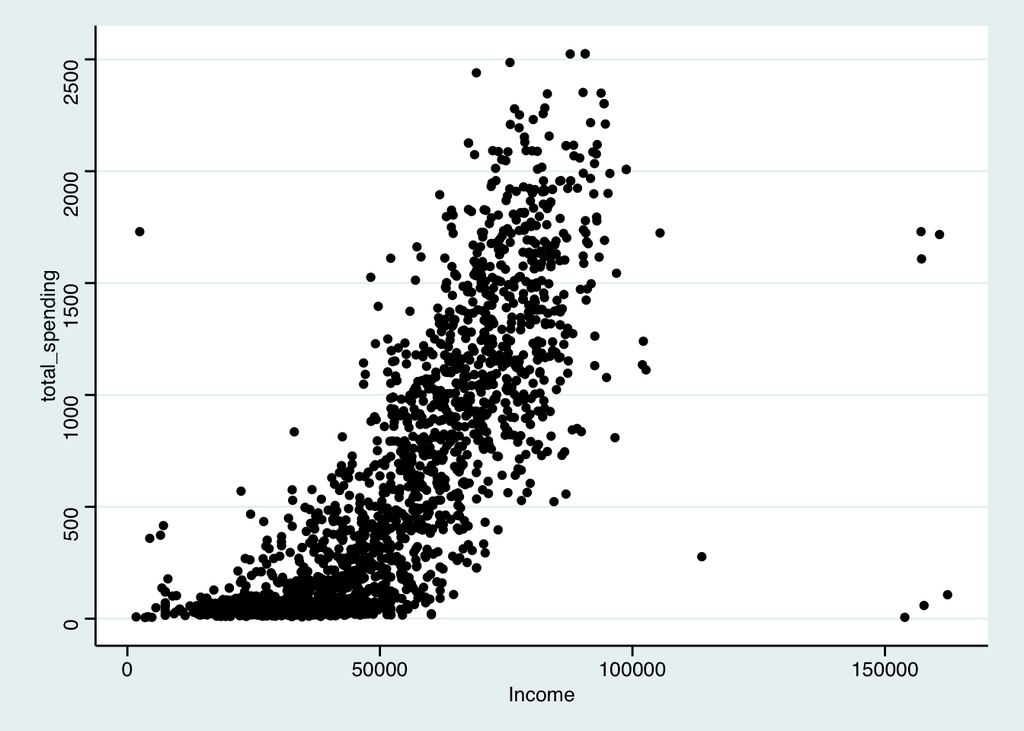

```r
ggplot(data = data_full,
       aes(x = Income, y = total_spending)) +
  geom_point()+theme_stata()
```

## 2.2 Quadratic Terms

- If after estimation, the coefficient for $Income^2$, $\beta_2$, is negative, then we have an down open parabola.

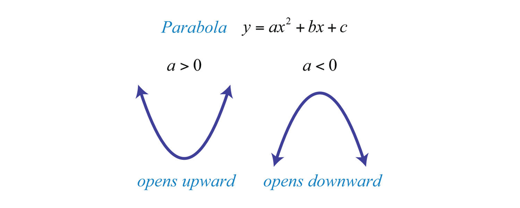

- That is, as income increases, total spending first increases and then decreases, i.e., a non-linear effect.

## 2.3 Quadratic Terms in Linear Regression

- Let’s run two regressions, with and without the quadratic term.

```r
data_full <- data_full %>%
  mutate(Income_quadartic = Income^2 )

# model 1: without quadratic term
feols_noquadratic <- feols(data = data_full,
  fml = total_spending ~ Income )

# model 2: with quadratic term
feols_quadratic <- feols(data = data_full,
  fml = total_spending ~ Income  + Income_quadartic )
```

```r
modelsummary(list(feols_noquadratic,feols_quadratic),
             stars = T)
```

|  | (1) | (2) |
| --- | --- | --- |
| (Intercept) | −556.823*** | −627.040*** |
|  | (21.654) | (36.522) |
| Income | 0.022*** | 0.025*** |
|  | (0.000) | (0.001) |
| Income_quadartic |  | 0.000* |
|  |  | (0.000) |
| Num.Obs. | 2000 | 2000 |
| R2 | 0.629 | 0.630 |
| R2 Adj. | 0.629 | 0.630 |
| AIC | 29306.1 | 29302.4 |
| BIC | 29317.3 | 29319.2 |
| RMSE | 367.45 | 366.92 |
| Std.Errors | IID | IID |

+ p < 0.1, * p < 0.05, ** p < 0.01, *** p < 0.001

## 2.4 Quadratic Terms: Compute the Vertex

- We can compute the vertex point where total spending is maximized by income

```r
# extract the coeffcient vector
feols_coefficient <- feols_quadratic$coefficients
feols_coefficient
```

```
     (Intercept)           Income Income_quadartic
   -6.270403e+02     2.533276e-02    -2.663682e-08
```

```r
# Use b / (-2a) to get the vertex
- feols_coefficient[2]/
  (2 * feols_coefficient[3])
```

```
  Income
475521.5
```

# 3 Linear Probability Model

## 3.1 Linear Probability Model

- In Predictive Analytics, we learned how to use decision tree and random forest to make predictions. In fact, linear regression can also be used as another supervised learning model.
- On the one hand, regression predicts the expectation of response $Y$ conditional on $X$; that is
  $$E[Y|X]= X\beta$$
- On the other hand, for a binary outcome variable, if the probability of outcome occurring is $p$, then we can write the expectation of $Y$ is
  $$E[Y|X] = 1 * p + 0 * (1 - p) = p$$
- As a result, we have the following equation
  $$\operatorname{Probability}[Y=1|X] = E[Y|X] = X \beta$$
- Interpretation of LPM: Everything else equal, a unit change in $x$ will change the probability of the outcome occurring by $\beta$ units.

## 3.2 Pros and Cons of LPM

- The procedures of training LPM is similar to training a decision tree `rpart()`/random forest `ranger()`: we use linear regression function `feols()` to train the LPM on the **training data** and make predictions on the **test data**.
- Advantages
  - Easy and fast to run
  - High interpretability: coefficients have clear economic meanings
- Disadvantages
  - Predicted probabilities of occurring may fall out of the [0,1] range
  - Accuracy tends to be low